# U.S. Retail Sales Analytics & Forecasting

Valter Cheque

2025-09-21

**1. Project Overview**

This report documents my end-to-end workflow for analyzing U.S. retail weekly sales and producing forecasts. It covers data cleaning, exploratory analysis, model baselines (ARIMA, Prophet), and key insights for decision-making.

*Repository structure (abridged)*:

```
data/raw/                 # input files from Kaggle
data/processed/           # tidy outputs for analysis & app
scripts/01_data_cleaning.R
scripts/02_eda_visuals.R
scripts/03_forecasting.R
app/app.R                 # Shiny app
report/sales_analysis_report.Rmd  # this file
```

**2. Data and Assumptions**

Source. Kaggle “Walmart Recruiting – Store Sales Forecasting”. Granularity. Weekly sales per store and department. Target. Weekly_Sales aggregated to store-week for forecasting.

*Files used downstream*:

```
data/processed/store_weekly_sales.* (store-level weekly totals)

outputs/figures/*.png (EDA figures)

outputs/tables/*.csv (KPIs, missingness, metrics)
```

3. Quick KPIs

```r
# I read precomputed KPIs to keep the report fast and deterministic.
kpi_path <- file.path("..","outputs","tables","kpis.csv")
kpis <- readr::read_csv(kpi_path, show_col_types = FALSE)
kpis
```

| min_date | max_date | n_stores | n_depts | total_sales |
| --- | --- | --- | --- | --- |
| 2010-02-05 | 2012-10-26 | 45 | 81 | 6737218987 |

4. Data Quality Notes

```r
# I inspect missingness to guide cleaning and feature usage.
miss_path <- file.path("..", "outputs","tables","missingness_summary.csv")
missingness <- readr::read_csv(miss_path, show_col_types = FALSE)
knitr::kable(head(missingness, 15), caption = "Top columns by missing values")
```

Top columns by missing values

| column | n_missing |
| --- | --- |
| mark_down2 | 310322 |
| mark_down4 | 286603 |
| mark_down3 | 284479 |
| mark_down1 | 270889 |
| mark_down5 | 270138 |
| store | 0 |
| dept | 0 |
| date | 0 |
| weekly_sales | 0 |
| is_holiday | 0 |
| temperature | 0 |
| fuel_price | 0 |
| cpi | 0 |
| unemployment | 0 |
| type | 0 |

*Actionable points*:

```
Promotional markdown fields contain many missing values; in cleaning, I imputed 0 as “no promotion.”

CPI/Unemployment were imputed by store-median, then global median, to avoid discarding weeks.
```

5. Exploratory Analysis

5.1 Overall Weekly Trend

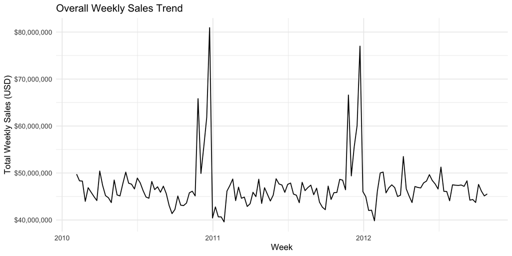

```r
knitr::include_graphics(file.path("..","outputs","figures","01_overall_weekly_sales_trend.png"))
```

Interpretation: I look for seasonality, structural breaks, and scale.

5.2 Top 10 Stores by Total Sales

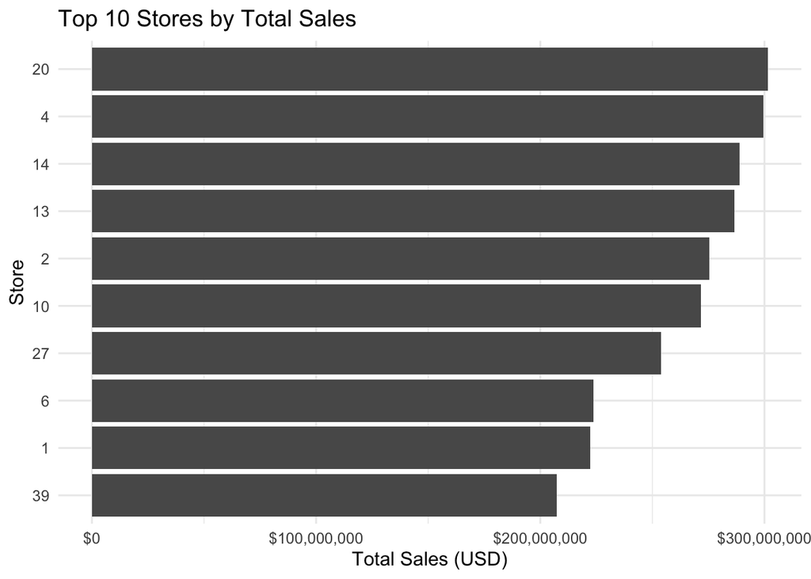

```r
knitr::include_graphics(file.path("..","outputs","figures","02_top10_stores_total_sales.png"))
```

5.3 Seasonality Heatmap (Monthly by Year)

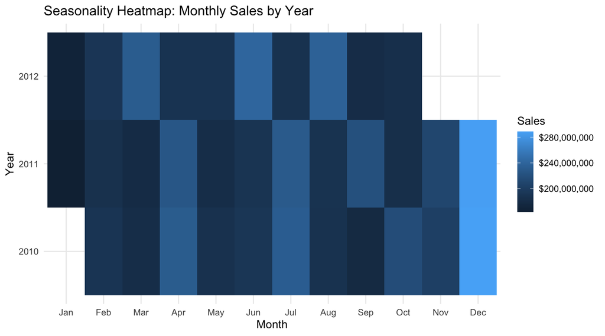

```r
knitr::include_graphics(file.path("..","outputs","figures","03_seasonality_heatmap_month_year.png"))
```

Interpretation: I confirm expected peaks near major U.S. holidays and evaluate month-over-month patterns.

5.4 Promotions vs Sales

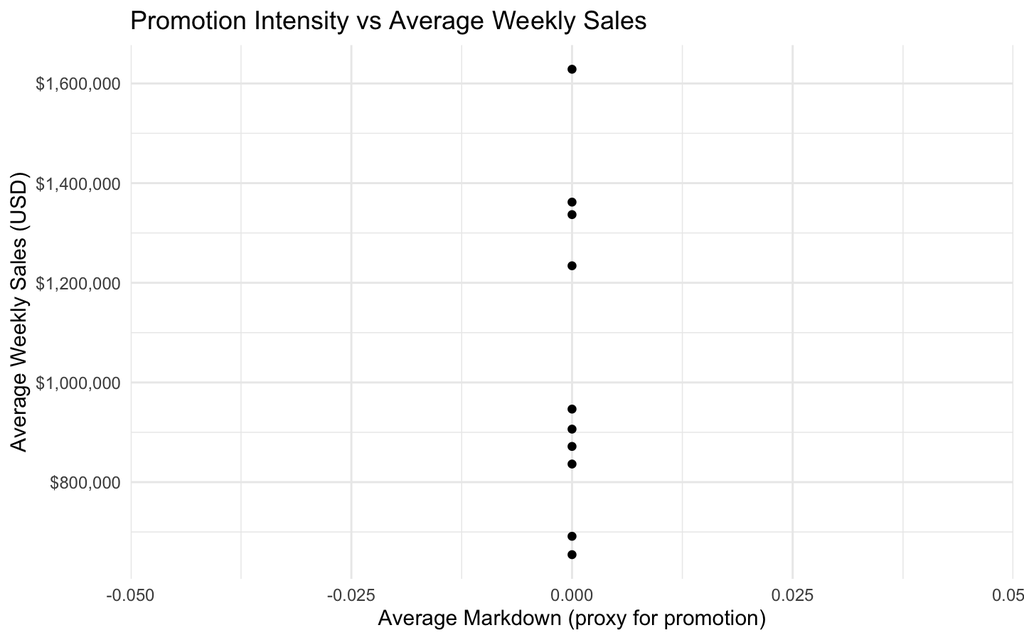

```r
knitr::include_graphics(file.path("..","outputs","figures","04_promotions_vs_sales.png"))
```

5.5 Holiday Effect

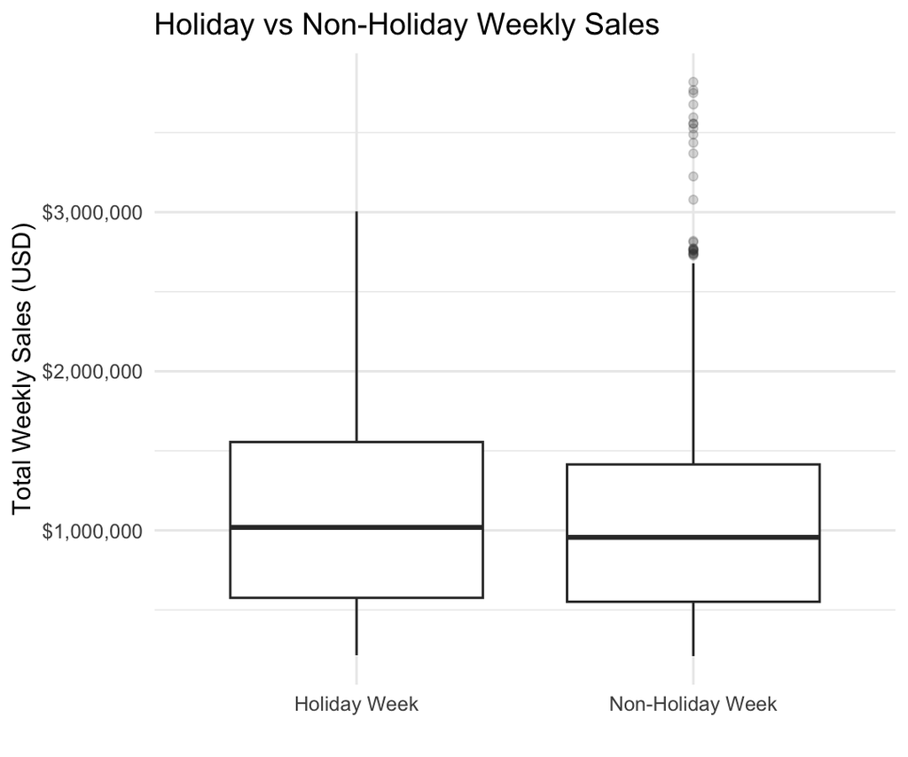

```r
knitr::include_graphics(file.path("..","outputs","figures","05_holiday_effect_boxplot.png"))
```

**6. Forecasting Design**

I forecast at the store-week level.

*Rationale*: this aligns with inventory and staffing decisions and avoids department noise.

*Holdout*. Last 12 weeks per store to simulate an unseen future. *Baselines*. ARIMA via auto.arima(); Prophet optional for cross-check.

*Key choices*:

```
Weekly frequency set to 52 for ARIMA seasonality detection.

Conservative Prophet priors to avoid overfitting.

Metrics: RMSE, MAE, and MAPE (excluding zero targets for stability).
```

*6.1 Per-Store Metrics*

```r
by_store <- readr::read_csv(file.path("..","outputs","tables","model_metrics_by_store.csv"), show_col_types = FALSE)
knitr::kable(by_store, caption = "Holdout metrics by store and model")
```

Holdout metrics by store and model

| store | model | RMSE | MAE | MAPE |
| --- | --- | --- | --- | --- |
| 20 | ARIMA | 78519.98 | 65441.37 | 3.156956 |
| 4 | ARIMA | 123739.35 | 108115.60 | 5.065795 |
| 14 | ARIMA | 156791.77 | 118128.25 | 7.238234 |
| 13 | ARIMA | 79142.66 | 55175.55 | 2.669480 |
| 2 | ARIMA | 56125.70 | 48106.25 | 2.550608 |
| 10 | ARIMA | 70530.59 | 55383.42 | 3.180806 |
| 27 | ARIMA | 102816.29 | 58861.72 | 3.428686 |
| 6 | ARIMA | 37812.20 | 32435.34 | 2.156004 |
| 1 | ARIMA | 43947.49 | 38153.94 | 2.480171 |
| 39 | ARIMA | 57529.41 | 42037.14 | 2.627252 |

*6.2 Summary Metrics*

```r
avg <- readr::read_csv(file.path("..","outputs","tables","model_metrics_avg.csv"), show_col_types = FALSE)
knitr::kable(avg, caption = "Average holdout metrics across evaluated stores")
```

Average holdout metrics across evaluated stores

| model | n_stores | RMSE | MAE | MAPE |
| --- | --- | --- | --- | --- |
| ARIMA | 10 | 80695.54 | 62183.86 | 3.455399 |

*6.3 Rolling-origin cross-validation (tsCV)*

I complement the last-12-weeks holdout with a rolling-origin backtest using `forecast::tsCV`, evaluating horizons 1..12 weeks ahead on the top stores by sales. This yields a more comprehensive picture of stability and multi-step performance.

```r
# Load precomputed metrics (from scripts/03b_backtesting.R)
path_avg <- file.path("..","outputs","tables","backtest_metrics_avg.csv")
path_store <- file.path("..","outputs","tables","backtest_metrics_by_store.csv")
path_hz <- file.path("..","outputs","tables","backtest_metrics_by_horizon.csv")

have_all <- file.exists(path_avg) && file.exists(path_store) && file.exists(path_hz)

if (have_all) {
  bt_avg   <- readr::read_csv(path_avg,   show_col_types = FALSE)
  bt_store <- readr::read_csv(path_store, show_col_types = FALSE)
  bt_hz    <- readr::read_csv(path_hz,    show_col_types = FALSE)
} else {
  cat("Backtest files not found. Run scripts/03b_backtesting.R and re-knit.\n")
}
```

```r
if (have_all) {
  knitr::kable(bt_avg, caption = "Rolling-origin CV — average metrics across evaluated stores")
}
```

Rolling-origin CV — average metrics across evaluated stores

| n_stores | RMSE | MAE |
| --- | --- | --- |
| 10 | 301699.1 | 165866.9 |

[figure not shown]

```r
if (have_all) {
  library(ggplot2)
  p <- ggplot(bt_hz, aes(horizon, RMSE, group = store)) +
    geom_line(alpha = 0.25) +
    stat_summary(fun = mean, geom = "line", linewidth = 1) +
    labs(title = "RMSE by Forecast Horizon (1..12 weeks)",
         x = "Horizon (weeks ahead)", y = "RMSE") +
    theme_minimal(base_size = 12)
  print(p)
}
```

**Notes**:

```
Lower RMSE/MAE indicate better absolute accuracy; lower MAPE indicates better relative accuracy.

If Prophet is unavailable locally, only ARIMA results are present.
```

**7. What I Would Deploy**

```
Baseline ARIMA per store for short-term planning (simple, transparent).

Add model monitoring: weekly backtests and error tracking.

Future work: hierarchical forecast (department → store → chain) and exogenous drivers (markdowns, holidays).
```

**8. Reproducibility**

```
Environment captured with renv.lock.

Deterministic outputs saved under outputs/.

To re-run:

  1. scripts/01_data_cleaning.R

  2. scripts/02_eda_visuals.R

  3. scripts/03_forecasting.R

  4. Knit this report.
```

## 7B) Knit the report

From RStudio: open `report/sales_analysis_report.Rmd` → Knit.  
This will create `report/sales_analysis_report.html` (self-contained).

## Report

- Full case study (GitHub Pages): https://github.com/VCheque/Sales-Analytics-Forecasting
- Raw HTML in this repo: report/sales_analysis_report.html